# Assignment 4

## Try to submit as an HTML file

Print your name below

```python
print("Sigrid Matthews")
```

[output not shown]

Import the numpy, matplotlib, and pandas packages

```python
# Write down your answer here:

import numpy as np
import pandas as pd
import matplotlib.pyplot as plt
```

(a) Create a sequence

- Create a value $n = 50$
- Create a list with the values $0,1,\ldots, n$
- Count the length of the list

```python
# Write your answer here
n = 50
list_n = list(range(0,n+1,1))
print(len(list_n))
```

```
51
```

(b) Counting True/False statements in a list

- Create

list_ages = [18, 20, 13, 15, 20, 35, 8, 7]

- Create an empty list "list_eligible_voter"
- Use a for-loop without numbering
  - Determine whether the age is $\ge 18$
  - Store the True/False result in "list_eligible_voter"
- Use "np.sum()" to count how many voters are eligible

Hint: Use the "append" function.

```python
# Write your answer here
list_ages = [18, 20, 13, 15, 20, 35, 8, 7]
list_eligible_voter = []
for ages in list_ages:
    list_eligible_voter.append(ages>=18)
np.sum(list_eligible_voter)
```

```
4
```

(c) Graphs from multiple datasets

- Create a list with the two "WDI" datasets for 2000, and 2020
- Run a for-loop over each dataset
  - Compute a histogram of "prop_urbanpopulation" for each year
  - Label the title with the name of the dataset

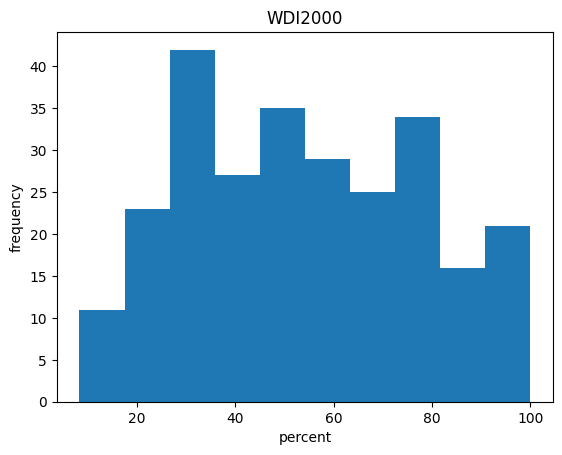

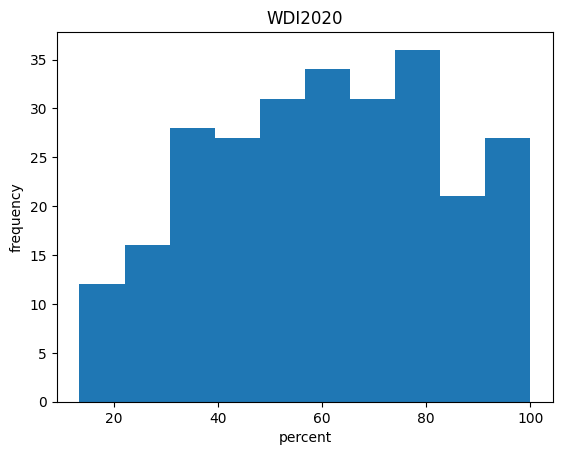

```python
# Note "prop_urbanpopulation" is the percentage of the urban population over
# the total population

# Hint: Before you write the loop, test your code out by opening an individual dataset
# Once you're sure the code works and you're familiar with the data, run the loop

# Write your answer here
wdi_2000 = pd.read_csv("wdi_data\wdi_2000.csv")
wdi_2020 = pd.read_csv("wdi_data\wdi_2020.csv")
wdis_list   = [wdi_2000, wdi_2020]

index=1
for list in wdis_list:
    plt.hist(list["prop_urbanpopulation"])
    plt.ylabel("frequency")
    plt.xlabel("percent")
    plt.title("WDI" + str(list.year[0]))
    plt.show()
index=index+1
```

For questions (d) and (e), use the following table:

[figure not shown]

(d) Loops with multiple lists

- Create three lists

list_lower = [93, 87, 83, 80, 75, 70, 65, 60, 55, 0]

list_upper = [100,92, 86, 82, 79, 74, 69, 64, 59, 54]

list_letters = ["A","A-","B+","B","B-","C+","C","C-","D","F"]

- Create a for loop that prints the message:

"If a students gets a grade between .... and ..., their letter grade is ..."

```python
# Hint: Use a for-loop with numbering
# Start the index at zero
# In the body of the loop, extract the elements in each list by the index position

# Write your answer here
list_lower = [93, 87, 83, 80, 75, 70, 65, 60, 55, 0]
list_upper = [100,92, 86, 82, 79, 74, 69, 64, 59, 54]
list_letters = ["A","A-","B+","B","B-","C+","C","C-","D","F"]

l=len(list_lower)
index= 0
for i in range(l):
    print("If a student gets a grade between "+ str(list_lower[i])+ "and"+ str(list_upper[i])+", their letter grade is "+str(list_letters[i]))
index=index+1
```

```
If a student gets a grade between 93and100, their letter grade is A
If a student gets a grade between 87and92, their letter grade is A-
If a student gets a grade between 83and86, their letter grade is B+
If a student gets a grade between 80and82, their letter grade is B
If a student gets a grade between 75and79, their letter grade is B-
If a student gets a grade between 70and74, their letter grade is C+
If a student gets a grade between 65and69, their letter grade is C
If a student gets a grade between 60and64, their letter grade is C-
If a student gets a grade between 55and59, their letter grade is D
If a student gets a grade between 0and54, their letter grade is F
```

(e) Classification with double loops

- Suppose that 5 students get the following grades:

list_studentgrades = [80, 92, 60, 42, 97]

- Print the following message:

"The student got a numeric grade of .... and their letter grade was ..."

```python
#(a) Hint: Use a double for loop structure:
#---- for studentgrade in list_studentgrades:
#----     index = 0
#----     for letter in list_letters:
#----          Body
#----          index = index + 1

# (b) Inside the body, use an if/else statement to print the correct letter grade.
# You can make your code more concise by doing similar steps to question (d).

# Write your answer here:

list_studentgrades = [80, 92, 60, 42, 97]

for student_grade in list_studentgrades:
    index = 0
    for letter in list_letters:
        if student_grade>93:
            letter="A"
        elif 87<=student_grade<=92:
            letter="A-"
        elif 83<=student_grade<=86:
            letter="B+"
        elif 80<=student_grade<=82:
            letter="B"
        elif 75<=student_grade<=79:
            letter="B-"
        elif 70<=student_grade<=74:
            letter="C+"
        elif 65<=student_grade<=69:
            letter="C"
        elif 60<=student_grade<=64:
            letter="C-"
        elif 55<=student_grade<=59:
            letter="D"
        else:
            letter= "F"
    print("the student got a numeric grade of "+str(student_grade)+" and their letter grade was "+str(letter))
    index=index+1
```

```
the student got a numeric grade of 80 and their letter grade was B
the student got a numeric grade of 92 and their letter grade was A-
the student got a numeric grade of 60 and their letter grade was C-
the student got a numeric grade of 42 and their letter grade was F
the student got a numeric grade of 97 and their letter grade was A
```